# SEATRAC Introduction to R: Session 2

Ling Wei & Shuyi Ma | adapted from the materials by Kim Dill-McFarland’s [BIGslu tidyverse workshop](https://bigslu.github.io/workshops/2022.08.15_R.tidyverse.workshop/2_tidyverse.html#2_Introduction_to_the_tidyverse)

2026-01-07

# Overview

In this session, we will introduce you to data manipulation and visualization using `tidyverse`, a collection of R packages for data science. We will cover the following topics:

- retrieving data frame specifications
- chaining sequences of operations (pipes)
- manipulating data frames (select, add, rearrange columns/rows)
- calculating statistics for the data
- data visualization (scatter plot, box plot)

## Data specifications

`tidyverse` is not loaded on R by default. We will load `tidyverse` first. If the package has not been installed yet, then we will need to use the `install.packages()` function to install first.

```r
library(tidyverse)
```

We will use the toy heart disease dataset to demonstrate the use of tidyverse for data manipulation and visualization in this session. Here is the link to download: Heart_Disease_100sampled.csv

(Note: this spreadsheet is a sub-sampled dataset from [kaggle](https://www.kaggle.com/datasets/oktayrdeki/heart-disease/data).)

```r
data <- read_csv("Heart_Disease_100sampled.csv")
```

Let’s first check the dimension of the data.

```r
dim(data)
```

```
## [1] 100  22
```

This dataset contains 100 rows (not including header) and 22 columns.

We can extract and display the full column specification for the data.

```r
spec(data)
```

[output not shown]

This will tell you the data types (e.g., character, double, integer, logical) for each column in the data frame.

If you’d like to have a better idea about the structure or content of the data:

```r
View(data)
```

This will open a new tab to display data in a table format, where you can browse, sort, or search within the data, but you cannot edit the data (read-only) through this interface.

## Pipes

Oftentimes your code contains multiple nested parenthesis, which makes it hard to read and understand. The pipe operator `%>%` allows you to transform complex nested operations into a linear sequence of operations, significantly increase the readability of the code.

Another potential advantage is that if you use a pipe to perform a series of operations, then you also won’t need to store intermediate outputs as separate variables. This might make it easier to keep track of which output variables you actually care about.

I will write the code in both conventional and piped formats in this session. Feel free to use whichever you are more comfortable with!

## Columns

We will work on data frame columns first. To pick specific columns from a data frame, you can use the `select()` function in `dplyr` package and refer to columns by name, position, or specific criteria.

To select a single column by name:

```r
# conventional
select(data, ptID)
```

```
## # A tibble: 100 × 1
##    ptID
##    <chr>
##  1 pt 7186
##  2 pt 7572
##  3 pt 2570
##  4 pt 8253
##  5 pt 5216
##  6 pt 3775
##  7 pt 7529
##  8 pt 8049
##  9 pt 1862
## 10 pt 8058
## # ℹ 90 more rows
```

```r
# piped
data %>%
  select(ptID)
```

```
## # A tibble: 100 × 1
##    ptID
##    <chr>
##  1 pt 7186
##  2 pt 7572
##  3 pt 2570
##  4 pt 8253
##  5 pt 5216
##  6 pt 3775
##  7 pt 7529
##  8 pt 8049
##  9 pt 1862
## 10 pt 8058
## # ℹ 90 more rows
```

To select multiple columns by name:

```r
# conventional
select(data, ptID, `Triglyceride Level`, `Heart Disease Status`)
```

```
## # A tibble: 100 × 3
##    ptID    `Triglyceride Level` `Heart Disease Status`
##    <chr>                  <dbl> <chr>
##  1 pt 7186                  225 No
##  2 pt 7572                  270 No
##  3 pt 2570                  242 No
##  4 pt 8253                  375 Yes
##  5 pt 5216                  202 No
##  6 pt 3775                  100 No
##  7 pt 7529                  359 No
##  8 pt 8049                  178 Yes
##  9 pt 1862                  259 No
## 10 pt 8058                  318 Yes
## # ℹ 90 more rows
```

```r
# piped
data %>%
  select(ptID, `Triglyceride Level`, `Heart Disease Status`)
```

```
## # A tibble: 100 × 3
##    ptID    `Triglyceride Level` `Heart Disease Status`
##    <chr>                  <dbl> <chr>
##  1 pt 7186                  225 No
##  2 pt 7572                  270 No
##  3 pt 2570                  242 No
##  4 pt 8253                  375 Yes
##  5 pt 5216                  202 No
##  6 pt 3775                  100 No
##  7 pt 7529                  359 No
##  8 pt 8049                  178 Yes
##  9 pt 1862                  259 No
## 10 pt 8058                  318 Yes
## # ℹ 90 more rows
```

You can also select all columns between two specific columns in a data frame by specifying the names of the first and the last columns that you’d like to include.

```r
# conventional
select(data, ptID:BMI)
```

```
## # A tibble: 100 × 10
##    ptID      Age Gender `Blood Pressure` `Cholesterol Level` `Exercise Habits`
##    <chr>   <dbl> <chr>             <dbl>               <dbl> <chr>
##  1 pt 7186    51 Male                139                 166 Low
##  2 pt 7572    63 Female              142                 175 Low
##  3 pt 2570    77 Male                140                 284 High
##  4 pt 8253    35 Female              172                 162 Medium
##  5 pt 5216    29 Female              165                 251 High
##  6 pt 3775    73 Male                180                 262 High
##  7 pt 7529    67 Female              129                 231 Low
##  8 pt 8049    56 Female              132                 187 Medium
##  9 pt 1862    38 Male                122                 183 Medium
## 10 pt 8058    29 Male                130                 237 High
## # ℹ 90 more rows
## # ℹ 4 more variables: Smoking <chr>, `Family Heart Disease` <chr>,
## #   Diabetes <chr>, BMI <dbl>
```

```r
# piped
data %>%
  select(ptID:BMI)
```

```
## # A tibble: 100 × 10
##    ptID      Age Gender `Blood Pressure` `Cholesterol Level` `Exercise Habits`
##    <chr>   <dbl> <chr>             <dbl>               <dbl> <chr>
##  1 pt 7186    51 Male                139                 166 Low
##  2 pt 7572    63 Female              142                 175 Low
##  3 pt 2570    77 Male                140                 284 High
##  4 pt 8253    35 Female              172                 162 Medium
##  5 pt 5216    29 Female              165                 251 High
##  6 pt 3775    73 Male                180                 262 High
##  7 pt 7529    67 Female              129                 231 Low
##  8 pt 8049    56 Female              132                 187 Medium
##  9 pt 1862    38 Male                122                 183 Medium
## 10 pt 8058    29 Male                130                 237 High
## # ℹ 90 more rows
## # ℹ 4 more variables: Smoking <chr>, `Family Heart Disease` <chr>,
## #   Diabetes <chr>, BMI <dbl>
```

This will give you all the columns in the example dataset between (and including) columns “ptID” and “BMI”.

You can use the `select()` function to exclude one particular column in a data frame. For instance, if you want to retrieve all the measurements in the example dataset except for sleep hours, you can simply specify its column name with the `!`:

```r
# conventional
select(data, !`Sleep Hours`)
```

```
## # A tibble: 100 × 21
##    ptID      Age Gender `Blood Pressure` `Cholesterol Level` `Exercise Habits`
##    <chr>   <dbl> <chr>             <dbl>               <dbl> <chr>
##  1 pt 7186    51 Male                139                 166 Low
##  2 pt 7572    63 Female              142                 175 Low
##  3 pt 2570    77 Male                140                 284 High
##  4 pt 8253    35 Female              172                 162 Medium
##  5 pt 5216    29 Female              165                 251 High
##  6 pt 3775    73 Male                180                 262 High
##  7 pt 7529    67 Female              129                 231 Low
##  8 pt 8049    56 Female              132                 187 Medium
##  9 pt 1862    38 Male                122                 183 Medium
## 10 pt 8058    29 Male                130                 237 High
## # ℹ 90 more rows
## # ℹ 15 more variables: Smoking <chr>, `Family Heart Disease` <chr>,
## #   Diabetes <chr>, BMI <dbl>, `High Blood Pressure` <chr>,
## #   `Low HDL Cholesterol` <chr>, `High LDL Cholesterol` <chr>,
## #   `Alcohol Consumption` <chr>, `Stress Level` <chr>,
## #   `Sugar Consumption` <chr>, `Triglyceride Level` <dbl>,
## #   `Fasting Blood Sugar` <dbl>, `CRP Level` <dbl>, …
```

```r
# piped
data %>%
  select(!`Sleep Hours`)
```

```
## # A tibble: 100 × 21
##    ptID      Age Gender `Blood Pressure` `Cholesterol Level` `Exercise Habits`
##    <chr>   <dbl> <chr>             <dbl>               <dbl> <chr>
##  1 pt 7186    51 Male                139                 166 Low
##  2 pt 7572    63 Female              142                 175 Low
##  3 pt 2570    77 Male                140                 284 High
##  4 pt 8253    35 Female              172                 162 Medium
##  5 pt 5216    29 Female              165                 251 High
##  6 pt 3775    73 Male                180                 262 High
##  7 pt 7529    67 Female              129                 231 Low
##  8 pt 8049    56 Female              132                 187 Medium
##  9 pt 1862    38 Male                122                 183 Medium
## 10 pt 8058    29 Male                130                 237 High
## # ℹ 90 more rows
## # ℹ 15 more variables: Smoking <chr>, `Family Heart Disease` <chr>,
## #   Diabetes <chr>, BMI <dbl>, `High Blood Pressure` <chr>,
## #   `Low HDL Cholesterol` <chr>, `High LDL Cholesterol` <chr>,
## #   `Alcohol Consumption` <chr>, `Stress Level` <chr>,
## #   `Sugar Consumption` <chr>, `Triglyceride Level` <dbl>,
## #   `Fasting Blood Sugar` <dbl>, `CRP Level` <dbl>, …
```

Column names can be changed as well if you are not happy with them (e.g., you can add spaces or not change to a more descriptive name). You can use the `rename()` function in `dplyr` package to do it.

```r
# conventional
rename(data, Blood_pressure = `Blood Pressure`)
```

```
## # A tibble: 100 × 22
##    ptID      Age Gender Blood_pressure `Cholesterol Level` `Exercise Habits`
##    <chr>   <dbl> <chr>           <dbl>               <dbl> <chr>
##  1 pt 7186    51 Male              139                 166 Low
##  2 pt 7572    63 Female            142                 175 Low
##  3 pt 2570    77 Male              140                 284 High
##  4 pt 8253    35 Female            172                 162 Medium
##  5 pt 5216    29 Female            165                 251 High
##  6 pt 3775    73 Male              180                 262 High
##  7 pt 7529    67 Female            129                 231 Low
##  8 pt 8049    56 Female            132                 187 Medium
##  9 pt 1862    38 Male              122                 183 Medium
## 10 pt 8058    29 Male              130                 237 High
## # ℹ 90 more rows
## # ℹ 16 more variables: Smoking <chr>, `Family Heart Disease` <chr>,
## #   Diabetes <chr>, BMI <dbl>, `High Blood Pressure` <chr>,
## #   `Low HDL Cholesterol` <chr>, `High LDL Cholesterol` <chr>,
## #   `Alcohol Consumption` <chr>, `Stress Level` <chr>, `Sleep Hours` <dbl>,
## #   `Sugar Consumption` <chr>, `Triglyceride Level` <dbl>,
## #   `Fasting Blood Sugar` <dbl>, `CRP Level` <dbl>, …
```

```r
# piped
data %>%
  rename(Blood_pressure = `Blood Pressure`)
```

```
## # A tibble: 100 × 22
##    ptID      Age Gender Blood_pressure `Cholesterol Level` `Exercise Habits`
##    <chr>   <dbl> <chr>           <dbl>               <dbl> <chr>
##  1 pt 7186    51 Male              139                 166 Low
##  2 pt 7572    63 Female            142                 175 Low
##  3 pt 2570    77 Male              140                 284 High
##  4 pt 8253    35 Female            172                 162 Medium
##  5 pt 5216    29 Female            165                 251 High
##  6 pt 3775    73 Male              180                 262 High
##  7 pt 7529    67 Female            129                 231 Low
##  8 pt 8049    56 Female            132                 187 Medium
##  9 pt 1862    38 Male              122                 183 Medium
## 10 pt 8058    29 Male              130                 237 High
## # ℹ 90 more rows
## # ℹ 16 more variables: Smoking <chr>, `Family Heart Disease` <chr>,
## #   Diabetes <chr>, BMI <dbl>, `High Blood Pressure` <chr>,
## #   `Low HDL Cholesterol` <chr>, `High LDL Cholesterol` <chr>,
## #   `Alcohol Consumption` <chr>, `Stress Level` <chr>, `Sleep Hours` <dbl>,
## #   `Sugar Consumption` <chr>, `Triglyceride Level` <dbl>,
## #   `Fasting Blood Sugar` <dbl>, `CRP Level` <dbl>, …
```

This will replace the space with an underscore in column “Blood Pressure”.

Note: the `if_else()` function has a 3 required inputs: your conditional statement, the output if true, the output if false.

```r
# conventional
data_new <- mutate(data, `Sleep Hours Recommended` = if_else(`Sleep Hours` > 7.0, "Yes", "No"))

# piped
data_new <- data %>%
  mutate(`Sleep Hours Recommended` = if_else(`Sleep Hours` > 7.0, "Yes", "No"))
```

This will add a new column of character data type named “Sleep Hours Recommended” to the end of the original data frame.

```r
View(data_new)
```

If you’d like to move this new column right after the “Sleep Hours” column, you can use the `relocate()` function in `dplyr` package to do it.

```r
# conventional
relocate(data_new, `Sleep Hours Recommended`, .after = `Sleep Hours`)
```

```
## # A tibble: 100 × 23
##    ptID      Age Gender `Blood Pressure` `Cholesterol Level` `Exercise Habits`
##    <chr>   <dbl> <chr>             <dbl>               <dbl> <chr>
##  1 pt 7186    51 Male                139                 166 Low
##  2 pt 7572    63 Female              142                 175 Low
##  3 pt 2570    77 Male                140                 284 High
##  4 pt 8253    35 Female              172                 162 Medium
##  5 pt 5216    29 Female              165                 251 High
##  6 pt 3775    73 Male                180                 262 High
##  7 pt 7529    67 Female              129                 231 Low
##  8 pt 8049    56 Female              132                 187 Medium
##  9 pt 1862    38 Male                122                 183 Medium
## 10 pt 8058    29 Male                130                 237 High
## # ℹ 90 more rows
## # ℹ 17 more variables: Smoking <chr>, `Family Heart Disease` <chr>,
## #   Diabetes <chr>, BMI <dbl>, `High Blood Pressure` <chr>,
## #   `Low HDL Cholesterol` <chr>, `High LDL Cholesterol` <chr>,
## #   `Alcohol Consumption` <chr>, `Stress Level` <chr>, `Sleep Hours` <dbl>,
## #   `Sleep Hours Recommended` <chr>, `Sugar Consumption` <chr>,
## #   `Triglyceride Level` <dbl>, `Fasting Blood Sugar` <dbl>, …
```

```r
# piped
data_new %>%
  relocate(`Sleep Hours Recommended`, .after = `Sleep Hours`)
```

```
## # A tibble: 100 × 23
##    ptID      Age Gender `Blood Pressure` `Cholesterol Level` `Exercise Habits`
##    <chr>   <dbl> <chr>             <dbl>               <dbl> <chr>
##  1 pt 7186    51 Male                139                 166 Low
##  2 pt 7572    63 Female              142                 175 Low
##  3 pt 2570    77 Male                140                 284 High
##  4 pt 8253    35 Female              172                 162 Medium
##  5 pt 5216    29 Female              165                 251 High
##  6 pt 3775    73 Male                180                 262 High
##  7 pt 7529    67 Female              129                 231 Low
##  8 pt 8049    56 Female              132                 187 Medium
##  9 pt 1862    38 Male                122                 183 Medium
## 10 pt 8058    29 Male                130                 237 High
## # ℹ 90 more rows
## # ℹ 17 more variables: Smoking <chr>, `Family Heart Disease` <chr>,
## #   Diabetes <chr>, BMI <dbl>, `High Blood Pressure` <chr>,
## #   `Low HDL Cholesterol` <chr>, `High LDL Cholesterol` <chr>,
## #   `Alcohol Consumption` <chr>, `Stress Level` <chr>, `Sleep Hours` <dbl>,
## #   `Sleep Hours Recommended` <chr>, `Sugar Consumption` <chr>,
## #   `Triglyceride Level` <dbl>, `Fasting Blood Sugar` <dbl>, …
```

## Rows

Let’s work on subsetting data frame rows using functions from the dplyr package. Similar to column manipulations, you can select specific rows from a data frame by position, value of a variable, or specific criteria.

For example, if you want to extract all the measurements for patients who smoke, you can use the `filter()` function to keep rows in the data frame that match this criteria:

```r
# conventional
filter(data, Smoking == "Yes")
```

```
## # A tibble: 58 × 22
##    ptID      Age Gender `Blood Pressure` `Cholesterol Level` `Exercise Habits`
##    <chr>   <dbl> <chr>             <dbl>               <dbl> <chr>
##  1 pt 7186    51 Male                139                 166 Low
##  2 pt 7572    63 Female              142                 175 Low
##  3 pt 2570    77 Male                140                 284 High
##  4 pt 3775    73 Male                180                 262 High
##  5 pt 8049    56 Female              132                 187 Medium
##  6 pt 7121    64 Female              180                 269 High
##  7 pt 5365    24 Male                161                 296 Low
##  8 pt 8323    73 Male                120                 259 Medium
##  9 pt 7365    51 Female              162                 278 Medium
## 10 pt 4966    53 Female              177                 255 High
## # ℹ 48 more rows
## # ℹ 16 more variables: Smoking <chr>, `Family Heart Disease` <chr>,
## #   Diabetes <chr>, BMI <dbl>, `High Blood Pressure` <chr>,
## #   `Low HDL Cholesterol` <chr>, `High LDL Cholesterol` <chr>,
## #   `Alcohol Consumption` <chr>, `Stress Level` <chr>, `Sleep Hours` <dbl>,
## #   `Sugar Consumption` <chr>, `Triglyceride Level` <dbl>,
## #   `Fasting Blood Sugar` <dbl>, `CRP Level` <dbl>, …
```

```r
# piped
data %>%
  filter(Smoking == "Yes")
```

```
## # A tibble: 58 × 22
##    ptID      Age Gender `Blood Pressure` `Cholesterol Level` `Exercise Habits`
##    <chr>   <dbl> <chr>             <dbl>               <dbl> <chr>
##  1 pt 7186    51 Male                139                 166 Low
##  2 pt 7572    63 Female              142                 175 Low
##  3 pt 2570    77 Male                140                 284 High
##  4 pt 3775    73 Male                180                 262 High
##  5 pt 8049    56 Female              132                 187 Medium
##  6 pt 7121    64 Female              180                 269 High
##  7 pt 5365    24 Male                161                 296 Low
##  8 pt 8323    73 Male                120                 259 Medium
##  9 pt 7365    51 Female              162                 278 Medium
## 10 pt 4966    53 Female              177                 255 High
## # ℹ 48 more rows
## # ℹ 16 more variables: Smoking <chr>, `Family Heart Disease` <chr>,
## #   Diabetes <chr>, BMI <dbl>, `High Blood Pressure` <chr>,
## #   `Low HDL Cholesterol` <chr>, `High LDL Cholesterol` <chr>,
## #   `Alcohol Consumption` <chr>, `Stress Level` <chr>, `Sleep Hours` <dbl>,
## #   `Sugar Consumption` <chr>, `Triglyceride Level` <dbl>,
## #   `Fasting Blood Sugar` <dbl>, `CRP Level` <dbl>, …
```

You can also add more criteria to the selection using `&` (and) or `|` (or) operators. For instance, if you want to extract data from patients who not only smoke but also do not exercise regularly, simply add that condition into the argument like this:

```r
# conventional
filter(data, Smoking == "Yes" & `Exercise Habits` == "Low")
```

```
## # A tibble: 24 × 22
##    ptID      Age Gender `Blood Pressure` `Cholesterol Level` `Exercise Habits`
##    <chr>   <dbl> <chr>             <dbl>               <dbl> <chr>
##  1 pt 7186    51 Male                139                 166 Low
##  2 pt 7572    63 Female              142                 175 Low
##  3 pt 5365    24 Male                161                 296 Low
##  4 pt 5813    26 Male                174                 167 Low
##  5 pt 1722    26 Male                133                 251 Low
##  6 pt 3645    66 Male                170                 168 Low
##  7 pt 9009    57 Female              123                 269 Low
##  8 pt 2242    28 Male                169                 225 Low
##  9 pt 6948    63 Female              136                 180 Low
## 10 pt 5302    18 Male                128                 210 Low
## # ℹ 14 more rows
## # ℹ 16 more variables: Smoking <chr>, `Family Heart Disease` <chr>,
## #   Diabetes <chr>, BMI <dbl>, `High Blood Pressure` <chr>,
## #   `Low HDL Cholesterol` <chr>, `High LDL Cholesterol` <chr>,
## #   `Alcohol Consumption` <chr>, `Stress Level` <chr>, `Sleep Hours` <dbl>,
## #   `Sugar Consumption` <chr>, `Triglyceride Level` <dbl>,
## #   `Fasting Blood Sugar` <dbl>, `CRP Level` <dbl>, …
```

```r
# piped
data %>%
  filter(Smoking == "Yes" & `Exercise Habits` == "Low")
```

```
## # A tibble: 24 × 22
##    ptID      Age Gender `Blood Pressure` `Cholesterol Level` `Exercise Habits`
##    <chr>   <dbl> <chr>             <dbl>               <dbl> <chr>
##  1 pt 7186    51 Male                139                 166 Low
##  2 pt 7572    63 Female              142                 175 Low
##  3 pt 5365    24 Male                161                 296 Low
##  4 pt 5813    26 Male                174                 167 Low
##  5 pt 1722    26 Male                133                 251 Low
##  6 pt 3645    66 Male                170                 168 Low
##  7 pt 9009    57 Female              123                 269 Low
##  8 pt 2242    28 Male                169                 225 Low
##  9 pt 6948    63 Female              136                 180 Low
## 10 pt 5302    18 Male                128                 210 Low
## # ℹ 14 more rows
## # ℹ 16 more variables: Smoking <chr>, `Family Heart Disease` <chr>,
## #   Diabetes <chr>, BMI <dbl>, `High Blood Pressure` <chr>,
## #   `Low HDL Cholesterol` <chr>, `High LDL Cholesterol` <chr>,
## #   `Alcohol Consumption` <chr>, `Stress Level` <chr>, `Sleep Hours` <dbl>,
## #   `Sugar Consumption` <chr>, `Triglyceride Level` <dbl>,
## #   `Fasting Blood Sugar` <dbl>, `CRP Level` <dbl>, …
```

You can also subset rows by specifying their row indexes in a data frame using the `slice()` function in `dplyr` package.

```r
# conventional
slice(data, 20:50)
```

```
## # A tibble: 31 × 22
##    ptID      Age Gender `Blood Pressure` `Cholesterol Level` `Exercise Habits`
##    <chr>   <dbl> <chr>             <dbl>               <dbl> <chr>
##  1 pt 810     39 Male                140                 291 Medium
##  2 pt 4972    26 Male                164                 256 Medium
##  3 pt 8760    23 Male                180                 165 Medium
##  4 pt 5813    26 Male                174                 167 Low
##  5 pt 7704    31 Female              133                 291 High
##  6 pt 1722    26 Male                133                 251 Low
##  7 pt 6651    57 Male                162                 202 Medium
##  8 pt 3645    66 Male                170                 168 Low
##  9 pt 3409    53 Male                146                 219 High
## 10 pt 3880    75 Female              168                 244 High
## # ℹ 21 more rows
## # ℹ 16 more variables: Smoking <chr>, `Family Heart Disease` <chr>,
## #   Diabetes <chr>, BMI <dbl>, `High Blood Pressure` <chr>,
## #   `Low HDL Cholesterol` <chr>, `High LDL Cholesterol` <chr>,
## #   `Alcohol Consumption` <chr>, `Stress Level` <chr>, `Sleep Hours` <dbl>,
## #   `Sugar Consumption` <chr>, `Triglyceride Level` <dbl>,
## #   `Fasting Blood Sugar` <dbl>, `CRP Level` <dbl>, …
```

```r
# piped
data %>%
  slice(20:50)
```

```
## # A tibble: 31 × 22
##    ptID      Age Gender `Blood Pressure` `Cholesterol Level` `Exercise Habits`
##    <chr>   <dbl> <chr>             <dbl>               <dbl> <chr>
##  1 pt 810     39 Male                140                 291 Medium
##  2 pt 4972    26 Male                164                 256 Medium
##  3 pt 8760    23 Male                180                 165 Medium
##  4 pt 5813    26 Male                174                 167 Low
##  5 pt 7704    31 Female              133                 291 High
##  6 pt 1722    26 Male                133                 251 Low
##  7 pt 6651    57 Male                162                 202 Medium
##  8 pt 3645    66 Male                170                 168 Low
##  9 pt 3409    53 Male                146                 219 High
## 10 pt 3880    75 Female              168                 244 High
## # ℹ 21 more rows
## # ℹ 16 more variables: Smoking <chr>, `Family Heart Disease` <chr>,
## #   Diabetes <chr>, BMI <dbl>, `High Blood Pressure` <chr>,
## #   `Low HDL Cholesterol` <chr>, `High LDL Cholesterol` <chr>,
## #   `Alcohol Consumption` <chr>, `Stress Level` <chr>, `Sleep Hours` <dbl>,
## #   `Sugar Consumption` <chr>, `Triglyceride Level` <dbl>,
## #   `Fasting Blood Sugar` <dbl>, `CRP Level` <dbl>, …
```

This will give you all the rows between and including row 20 and row 50 in the example dataset.

If you want to get the first or the last number of rows from a data frame, use the `slice_head()` or `slice_tail()` function, respectively, and specify the number of rows you’d like to subset.

```r
# conventional
slice_head(data, n=5)
```

```
## # A tibble: 5 × 22
##   ptID      Age Gender `Blood Pressure` `Cholesterol Level` `Exercise Habits`
##   <chr>   <dbl> <chr>             <dbl>               <dbl> <chr>
## 1 pt 7186    51 Male                139                 166 Low
## 2 pt 7572    63 Female              142                 175 Low
## 3 pt 2570    77 Male                140                 284 High
## 4 pt 8253    35 Female              172                 162 Medium
## 5 pt 5216    29 Female              165                 251 High
## # ℹ 16 more variables: Smoking <chr>, `Family Heart Disease` <chr>,
## #   Diabetes <chr>, BMI <dbl>, `High Blood Pressure` <chr>,
## #   `Low HDL Cholesterol` <chr>, `High LDL Cholesterol` <chr>,
## #   `Alcohol Consumption` <chr>, `Stress Level` <chr>, `Sleep Hours` <dbl>,
## #   `Sugar Consumption` <chr>, `Triglyceride Level` <dbl>,
## #   `Fasting Blood Sugar` <dbl>, `CRP Level` <dbl>, `Homocysteine Level` <dbl>,
## #   `Heart Disease Status` <chr>
```

```r
slice_tail(data, n=5)
```

```
## # A tibble: 5 × 22
##   ptID      Age Gender `Blood Pressure` `Cholesterol Level` `Exercise Habits`
##   <chr>   <dbl> <chr>             <dbl>               <dbl> <chr>
## 1 pt 334     59 Male                154                 188 Medium
## 2 pt 2889    37 Male                167                 262 Medium
## 3 pt 4055    26 Male                123                 238 Low
## 4 pt 269     49 Female              156                 205 Medium
## 5 pt 2005    74 Female              141                 247 Low
## # ℹ 16 more variables: Smoking <chr>, `Family Heart Disease` <chr>,
## #   Diabetes <chr>, BMI <dbl>, `High Blood Pressure` <chr>,
## #   `Low HDL Cholesterol` <chr>, `High LDL Cholesterol` <chr>,
## #   `Alcohol Consumption` <chr>, `Stress Level` <chr>, `Sleep Hours` <dbl>,
## #   `Sugar Consumption` <chr>, `Triglyceride Level` <dbl>,
## #   `Fasting Blood Sugar` <dbl>, `CRP Level` <dbl>, `Homocysteine Level` <dbl>,
## #   `Heart Disease Status` <chr>
```

```r
# piped
data %>%
  slice_head(n=5)
```

```
## # A tibble: 5 × 22
##   ptID      Age Gender `Blood Pressure` `Cholesterol Level` `Exercise Habits`
##   <chr>   <dbl> <chr>             <dbl>               <dbl> <chr>
## 1 pt 7186    51 Male                139                 166 Low
## 2 pt 7572    63 Female              142                 175 Low
## 3 pt 2570    77 Male                140                 284 High
## 4 pt 8253    35 Female              172                 162 Medium
## 5 pt 5216    29 Female              165                 251 High
## # ℹ 16 more variables: Smoking <chr>, `Family Heart Disease` <chr>,
## #   Diabetes <chr>, BMI <dbl>, `High Blood Pressure` <chr>,
## #   `Low HDL Cholesterol` <chr>, `High LDL Cholesterol` <chr>,
## #   `Alcohol Consumption` <chr>, `Stress Level` <chr>, `Sleep Hours` <dbl>,
## #   `Sugar Consumption` <chr>, `Triglyceride Level` <dbl>,
## #   `Fasting Blood Sugar` <dbl>, `CRP Level` <dbl>, `Homocysteine Level` <dbl>,
## #   `Heart Disease Status` <chr>
```

```r
data %>%
  slice_tail(n=5)
```

```
## # A tibble: 5 × 22
##   ptID      Age Gender `Blood Pressure` `Cholesterol Level` `Exercise Habits`
##   <chr>   <dbl> <chr>             <dbl>               <dbl> <chr>
## 1 pt 334     59 Male                154                 188 Medium
## 2 pt 2889    37 Male                167                 262 Medium
## 3 pt 4055    26 Male                123                 238 Low
## 4 pt 269     49 Female              156                 205 Medium
## 5 pt 2005    74 Female              141                 247 Low
## # ℹ 16 more variables: Smoking <chr>, `Family Heart Disease` <chr>,
## #   Diabetes <chr>, BMI <dbl>, `High Blood Pressure` <chr>,
## #   `Low HDL Cholesterol` <chr>, `High LDL Cholesterol` <chr>,
## #   `Alcohol Consumption` <chr>, `Stress Level` <chr>, `Sleep Hours` <dbl>,
## #   `Sugar Consumption` <chr>, `Triglyceride Level` <dbl>,
## #   `Fasting Blood Sugar` <dbl>, `CRP Level` <dbl>, `Homocysteine Level` <dbl>,
## #   `Heart Disease Status` <chr>
```

You can also randomly select rows from a data frame. This can be done with the `slice_sample()` function in `dplyr` package. For instance, if you want to get data from 10 patients that are randomly sampled from the 100 patients in the example dataset:

```r
# conventional
slice_sample(data, n = 10)
```

```
## # A tibble: 10 × 22
##    ptID      Age Gender `Blood Pressure` `Cholesterol Level` `Exercise Habits`
##    <chr>   <dbl> <chr>             <dbl>               <dbl> <chr>
##  1 pt 5365    24 Male                161                 296 Low
##  2 pt 5096    51 Male                134                 291 Medium
##  3 pt 7054    66 Female              161                 150 High
##  4 pt 8049    56 Female              132                 187 Medium
##  5 pt 7597    24 Female              171                 222 Low
##  6 pt 5813    26 Male                174                 167 Low
##  7 pt 2578    19 Male                166                 182 High
##  8 pt 7916    60 Female              140                 262 Medium
##  9 pt 6684    80 Female              149                 161 Medium
## 10 pt 347     79 Female              124                 205 Medium
## # ℹ 16 more variables: Smoking <chr>, `Family Heart Disease` <chr>,
## #   Diabetes <chr>, BMI <dbl>, `High Blood Pressure` <chr>,
## #   `Low HDL Cholesterol` <chr>, `High LDL Cholesterol` <chr>,
## #   `Alcohol Consumption` <chr>, `Stress Level` <chr>, `Sleep Hours` <dbl>,
## #   `Sugar Consumption` <chr>, `Triglyceride Level` <dbl>,
## #   `Fasting Blood Sugar` <dbl>, `CRP Level` <dbl>, `Homocysteine Level` <dbl>,
## #   `Heart Disease Status` <chr>
```

```r
# piped
data %>%
  slice_sample(n = 10)
```

```
## # A tibble: 10 × 22
##    ptID      Age Gender `Blood Pressure` `Cholesterol Level` `Exercise Habits`
##    <chr>   <dbl> <chr>             <dbl>               <dbl> <chr>
##  1 pt 4055    26 Male                123                 238 Low
##  2 pt 8674    51 Female              142                 260 Medium
##  3 pt 3645    66 Male                170                 168 Low
##  4 pt 5252    18 Male                159                 266 High
##  5 pt 9471    37 Female              144                 297 High
##  6 pt 1862    38 Male                122                 183 Medium
##  7 pt 4258    78 Male                121                 191 Low
##  8 pt 3651    76 Male                138                 290 High
##  9 pt 5216    29 Female              165                 251 High
## 10 pt 334     59 Male                154                 188 Medium
## # ℹ 16 more variables: Smoking <chr>, `Family Heart Disease` <chr>,
## #   Diabetes <chr>, BMI <dbl>, `High Blood Pressure` <chr>,
## #   `Low HDL Cholesterol` <chr>, `High LDL Cholesterol` <chr>,
## #   `Alcohol Consumption` <chr>, `Stress Level` <chr>, `Sleep Hours` <dbl>,
## #   `Sugar Consumption` <chr>, `Triglyceride Level` <dbl>,
## #   `Fasting Blood Sugar` <dbl>, `CRP Level` <dbl>, `Homocysteine Level` <dbl>,
## #   `Heart Disease Status` <chr>
```

Row selections can also be done based on the values of a particular variable in a data frame. For example, you can use the `slice_min()` function to extract data from the five patients with the lowest BMI:

```r
# conventional
slice_min(data, order_by = BMI, n=5)
```

```
## # A tibble: 5 × 22
##   ptID      Age Gender `Blood Pressure` `Cholesterol Level` `Exercise Habits`
##   <chr>   <dbl> <chr>             <dbl>               <dbl> <chr>
## 1 pt 810     39 Male                140                 291 Medium
## 2 pt 5496    27 Male                142                 279 Low
## 3 pt 6710    33 Female              161                 270 High
## 4 pt 2475    62 Male                148                 193 Medium
## 5 pt 5252    18 Male                159                 266 High
## # ℹ 16 more variables: Smoking <chr>, `Family Heart Disease` <chr>,
## #   Diabetes <chr>, BMI <dbl>, `High Blood Pressure` <chr>,
## #   `Low HDL Cholesterol` <chr>, `High LDL Cholesterol` <chr>,
## #   `Alcohol Consumption` <chr>, `Stress Level` <chr>, `Sleep Hours` <dbl>,
## #   `Sugar Consumption` <chr>, `Triglyceride Level` <dbl>,
## #   `Fasting Blood Sugar` <dbl>, `CRP Level` <dbl>, `Homocysteine Level` <dbl>,
## #   `Heart Disease Status` <chr>
```

```r
# piped
data %>%
  slice_min(order_by = BMI, n=5)
```

```
## # A tibble: 5 × 22
##   ptID      Age Gender `Blood Pressure` `Cholesterol Level` `Exercise Habits`
##   <chr>   <dbl> <chr>             <dbl>               <dbl> <chr>
## 1 pt 810     39 Male                140                 291 Medium
## 2 pt 5496    27 Male                142                 279 Low
## 3 pt 6710    33 Female              161                 270 High
## 4 pt 2475    62 Male                148                 193 Medium
## 5 pt 5252    18 Male                159                 266 High
## # ℹ 16 more variables: Smoking <chr>, `Family Heart Disease` <chr>,
## #   Diabetes <chr>, BMI <dbl>, `High Blood Pressure` <chr>,
## #   `Low HDL Cholesterol` <chr>, `High LDL Cholesterol` <chr>,
## #   `Alcohol Consumption` <chr>, `Stress Level` <chr>, `Sleep Hours` <dbl>,
## #   `Sugar Consumption` <chr>, `Triglyceride Level` <dbl>,
## #   `Fasting Blood Sugar` <dbl>, `CRP Level` <dbl>, `Homocysteine Level` <dbl>,
## #   `Heart Disease Status` <chr>
```

Or if you want to get data from the five oldest patients, use the `slice_max()` function:

```r
# conventional
slice_max(data, order_by = Age, n=5)
```

```
## # A tibble: 5 × 22
##   ptID      Age Gender `Blood Pressure` `Cholesterol Level` `Exercise Habits`
##   <chr>   <dbl> <chr>             <dbl>               <dbl> <chr>
## 1 pt 6684    80 Female              149                 161 Medium
## 2 pt 151     79 Female              178                 162 High
## 3 pt 5177    79 Female              163                 286 Medium
## 4 pt 347     79 Female              124                 205 Medium
## 5 pt 4258    78 Male                121                 191 Low
## # ℹ 16 more variables: Smoking <chr>, `Family Heart Disease` <chr>,
## #   Diabetes <chr>, BMI <dbl>, `High Blood Pressure` <chr>,
## #   `Low HDL Cholesterol` <chr>, `High LDL Cholesterol` <chr>,
## #   `Alcohol Consumption` <chr>, `Stress Level` <chr>, `Sleep Hours` <dbl>,
## #   `Sugar Consumption` <chr>, `Triglyceride Level` <dbl>,
## #   `Fasting Blood Sugar` <dbl>, `CRP Level` <dbl>, `Homocysteine Level` <dbl>,
## #   `Heart Disease Status` <chr>
```

```r
# piped
data %>%
  slice_max(order_by = Age, n=5)
```

```
## # A tibble: 5 × 22
##   ptID      Age Gender `Blood Pressure` `Cholesterol Level` `Exercise Habits`
##   <chr>   <dbl> <chr>             <dbl>               <dbl> <chr>
## 1 pt 6684    80 Female              149                 161 Medium
## 2 pt 151     79 Female              178                 162 High
## 3 pt 5177    79 Female              163                 286 Medium
## 4 pt 347     79 Female              124                 205 Medium
## 5 pt 4258    78 Male                121                 191 Low
## # ℹ 16 more variables: Smoking <chr>, `Family Heart Disease` <chr>,
## #   Diabetes <chr>, BMI <dbl>, `High Blood Pressure` <chr>,
## #   `Low HDL Cholesterol` <chr>, `High LDL Cholesterol` <chr>,
## #   `Alcohol Consumption` <chr>, `Stress Level` <chr>, `Sleep Hours` <dbl>,
## #   `Sugar Consumption` <chr>, `Triglyceride Level` <dbl>,
## #   `Fasting Blood Sugar` <dbl>, `CRP Level` <dbl>, `Homocysteine Level` <dbl>,
## #   `Heart Disease Status` <chr>
```

You can also reorder the rows of the entire data frame based on values of one or more columns using the `arrange()` function in `dplyr` package. The rows are sorted in ascending order by default, but you can use the `desc()` helper function to sort in descending order.

```r
# conventional
arrange(data, Age) # ascending order
```

```
## # A tibble: 100 × 22
##    ptID      Age Gender `Blood Pressure` `Cholesterol Level` `Exercise Habits`
##    <chr>   <dbl> <chr>             <dbl>               <dbl> <chr>
##  1 pt 5302    18 Male                128                 210 Low
##  2 pt 5252    18 Male                159                 266 High
##  3 pt 2578    19 Male                166                 182 High
##  4 pt 2530    19 Female              179                 276 High
##  5 pt 8443    19 Female              161                 177 Medium
##  6 pt 2007    21 Female              128                 200 Low
##  7 pt 4875    22 Female              175                 179 Low
##  8 pt 5634    22 Male                153                 276 Low
##  9 pt 8760    23 Male                180                 165 Medium
## 10 pt 9056    23 Male                144                 265 High
## # ℹ 90 more rows
## # ℹ 16 more variables: Smoking <chr>, `Family Heart Disease` <chr>,
## #   Diabetes <chr>, BMI <dbl>, `High Blood Pressure` <chr>,
## #   `Low HDL Cholesterol` <chr>, `High LDL Cholesterol` <chr>,
## #   `Alcohol Consumption` <chr>, `Stress Level` <chr>, `Sleep Hours` <dbl>,
## #   `Sugar Consumption` <chr>, `Triglyceride Level` <dbl>,
## #   `Fasting Blood Sugar` <dbl>, `CRP Level` <dbl>, …
```

```r
arrange(data, desc(Age)) # descending order
```

```
## # A tibble: 100 × 22
##    ptID      Age Gender `Blood Pressure` `Cholesterol Level` `Exercise Habits`
##    <chr>   <dbl> <chr>             <dbl>               <dbl> <chr>
##  1 pt 6684    80 Female              149                 161 Medium
##  2 pt 151     79 Female              178                 162 High
##  3 pt 5177    79 Female              163                 286 Medium
##  4 pt 347     79 Female              124                 205 Medium
##  5 pt 4258    78 Male                121                 191 Low
##  6 pt 2570    77 Male                140                 284 High
##  7 pt 2458    77 Female              156                 189 High
##  8 pt 8360    77 Male                169                 197 High
##  9 pt 1845    76 Female              125                 244 Low
## 10 pt 1417    76 Male                137                 176 Low
## # ℹ 90 more rows
## # ℹ 16 more variables: Smoking <chr>, `Family Heart Disease` <chr>,
## #   Diabetes <chr>, BMI <dbl>, `High Blood Pressure` <chr>,
## #   `Low HDL Cholesterol` <chr>, `High LDL Cholesterol` <chr>,
## #   `Alcohol Consumption` <chr>, `Stress Level` <chr>, `Sleep Hours` <dbl>,
## #   `Sugar Consumption` <chr>, `Triglyceride Level` <dbl>,
## #   `Fasting Blood Sugar` <dbl>, `CRP Level` <dbl>, …
```

```r
#piped
data %>%
  arrange(Age) # ascending order
```

```
## # A tibble: 100 × 22
##    ptID      Age Gender `Blood Pressure` `Cholesterol Level` `Exercise Habits`
##    <chr>   <dbl> <chr>             <dbl>               <dbl> <chr>
##  1 pt 5302    18 Male                128                 210 Low
##  2 pt 5252    18 Male                159                 266 High
##  3 pt 2578    19 Male                166                 182 High
##  4 pt 2530    19 Female              179                 276 High
##  5 pt 8443    19 Female              161                 177 Medium
##  6 pt 2007    21 Female              128                 200 Low
##  7 pt 4875    22 Female              175                 179 Low
##  8 pt 5634    22 Male                153                 276 Low
##  9 pt 8760    23 Male                180                 165 Medium
## 10 pt 9056    23 Male                144                 265 High
## # ℹ 90 more rows
## # ℹ 16 more variables: Smoking <chr>, `Family Heart Disease` <chr>,
## #   Diabetes <chr>, BMI <dbl>, `High Blood Pressure` <chr>,
## #   `Low HDL Cholesterol` <chr>, `High LDL Cholesterol` <chr>,
## #   `Alcohol Consumption` <chr>, `Stress Level` <chr>, `Sleep Hours` <dbl>,
## #   `Sugar Consumption` <chr>, `Triglyceride Level` <dbl>,
## #   `Fasting Blood Sugar` <dbl>, `CRP Level` <dbl>, …
```

```r
data %>%
  arrange(desc(Age)) # descending order
```

```
## # A tibble: 100 × 22
##    ptID      Age Gender `Blood Pressure` `Cholesterol Level` `Exercise Habits`
##    <chr>   <dbl> <chr>             <dbl>               <dbl> <chr>
##  1 pt 6684    80 Female              149                 161 Medium
##  2 pt 151     79 Female              178                 162 High
##  3 pt 5177    79 Female              163                 286 Medium
##  4 pt 347     79 Female              124                 205 Medium
##  5 pt 4258    78 Male                121                 191 Low
##  6 pt 2570    77 Male                140                 284 High
##  7 pt 2458    77 Female              156                 189 High
##  8 pt 8360    77 Male                169                 197 High
##  9 pt 1845    76 Female              125                 244 Low
## 10 pt 1417    76 Male                137                 176 Low
## # ℹ 90 more rows
## # ℹ 16 more variables: Smoking <chr>, `Family Heart Disease` <chr>,
## #   Diabetes <chr>, BMI <dbl>, `High Blood Pressure` <chr>,
## #   `Low HDL Cholesterol` <chr>, `High LDL Cholesterol` <chr>,
## #   `Alcohol Consumption` <chr>, `Stress Level` <chr>, `Sleep Hours` <dbl>,
## #   `Sugar Consumption` <chr>, `Triglyceride Level` <dbl>,
## #   `Fasting Blood Sugar` <dbl>, `CRP Level` <dbl>, …
```

## Statistics

To calculate some summary statistics for the data, you can use the `summarise()` function in `dplyr` package, which reduces multiple values from a data frame into a single or multiple summary statistics.

```r
# center of the data - mean and median
summarise(data, mean(BMI), median(BMI)) # conventional
```

```
## # A tibble: 1 × 2
##   `mean(BMI)` `median(BMI)`
##         <dbl>         <dbl>
## 1        29.0          29.5
```

```r
data %>%
  summarise(mean(BMI), median(BMI)) # piped
```

```
## # A tibble: 1 × 2
##   `mean(BMI)` `median(BMI)`
##         <dbl>         <dbl>
## 1        29.0          29.5
```

```r
# spread of the data - standard deviation and variance
summarise(data, sd(BMI), var(BMI)) # conventional
```

```
## # A tibble: 1 × 2
##   `sd(BMI)` `var(BMI)`
##       <dbl>      <dbl>
## 1      5.97       35.7
```

```r
data %>%
  summarise(sd(BMI), var(BMI)) # piped
```

```
## # A tibble: 1 × 2
##   `sd(BMI)` `var(BMI)`
##       <dbl>      <dbl>
## 1      5.97       35.7
```

```r
# range of the data - minimum and maximum
summarise(data, min(BMI), max(BMI)) # conventional
```

```
## # A tibble: 1 × 2
##   `min(BMI)` `max(BMI)`
##        <dbl>      <dbl>
## 1       18.2       39.8
```

```r
data %>%
  summarise(min(BMI), max(BMI)) # piped
```

```
## # A tibble: 1 × 2
##   `min(BMI)` `max(BMI)`
##        <dbl>      <dbl>
## 1       18.2       39.8
```

## Getting help

If you want to learn more about the `dplyr` package, please refer to this “Introduction to dplyr” guide, which provides a comprehensive and detailed description of the package (including examples).

```r
vignette("dplyr")
```

```
## starting httpd help server ... done
```

## Data visualization

We will make some simple plots from the toy dataset using `ggplot2`, a widely used R package for data visualization. `ggplot2` allows you to build complex plots layer by layer through the `+` operator. You will first use `ggplot()` to define the plot and aesthetic mappings (e.g., axes, color, size). You will then add layers to define the geometry (e.g., points, lines, bars) of the plot. You can also add layers to create subplots, add title and axis labels, and save the plot.

# scatter plot

We will start with scatter plots. We will make a basic scatter plot of “Fasting Blood Sugar” against “Homocysteine Level” using the default settings.

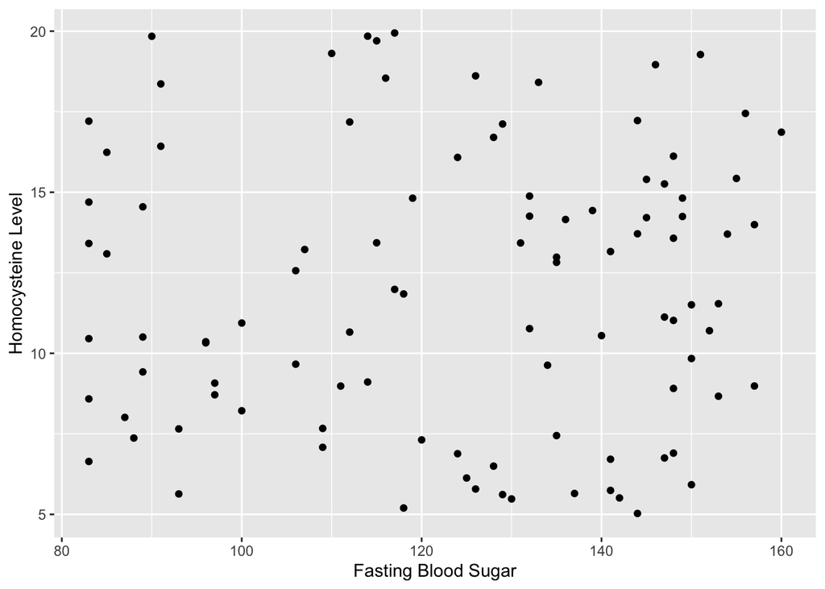

```r
# plotting fasting blood sugar vs. homocysteine levels of patients
data %>%
  ggplot(aes(x = `Fasting Blood Sugar`, y = `Homocysteine Level`)) +
  geom_point()
```

We can color code the data points by gender by adding a `color` argument.

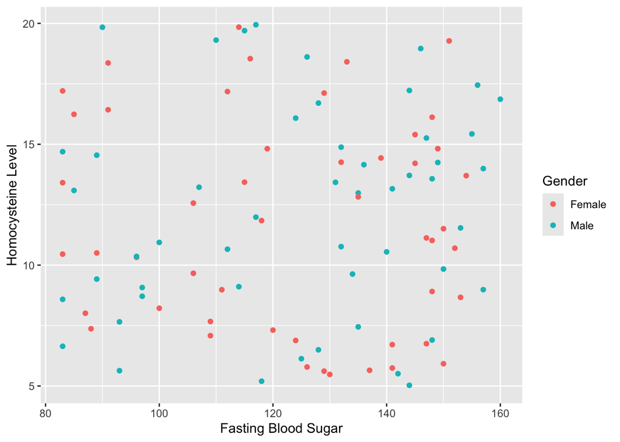

```r
data %>%
  ggplot(aes(x = `Fasting Blood Sugar`, y = `Homocysteine Level`, color = Gender)) +
  geom_point()
```

To help visualize patterns and trends in the data, you can use the `geom_smooth()` function to fit a model to the data and overlay a trend line to the plot. It also displays shaded 95% confidence interval by default (you can hide or adjust it in the arguments). You can specify the function to use for fitting the model (smoothing function) via the `method` argument.

For example, if you want to add linear regression lines to the plot above, you can add a layer of smoothing function `geom_smooth()` and put `lm` in the “method” argument.

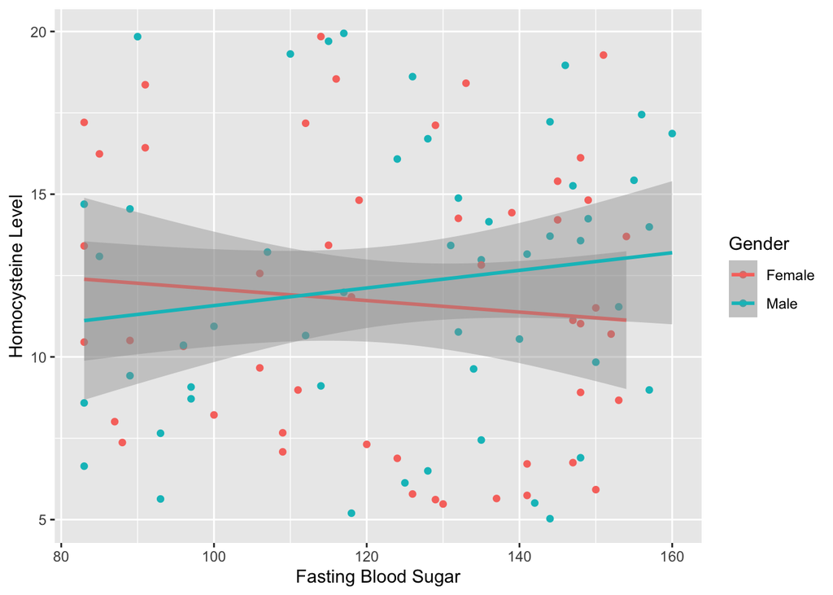

```r
data %>%
  ggplot(aes(x = `Fasting Blood Sugar`, y = `Homocysteine Level`, color = Gender)) +
  geom_point() +
  geom_smooth(method = "lm", se = TRUE)
```

Since we group the data by gender here, the fitting is applied to female and male patient data separately.

# box-and-whisker plot

We will make some box-and-whisker plots to visualize the distribution of data between groups. We will start with a basic box plot on triglyceride level for patients with or without heart disease. We will use `geom_boxplot()` to define the box plot. If you want the y axis to show the full data range and hide the outliers, specify in the argument with `outlier.shape = NA`. You can use the `geom_jitter()` function to display individual data points, which also adds a small amount of random noise to the position (horizontal in this case) of each point for easy visualization.

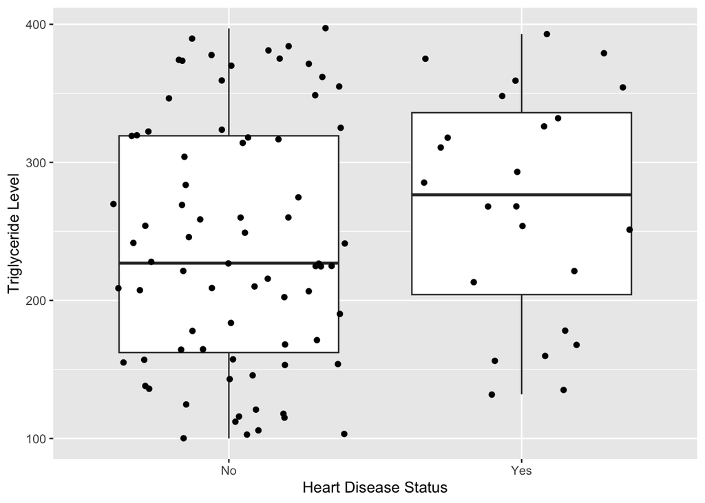

```r
data %>%
  ggplot(aes(x = `Heart Disease Status`, y = `Triglyceride Level`)) +
  geom_boxplot(outlier.shape = NA) +
  geom_jitter()
```

By default, `geom_boxplot()` does not include error bars (or whisker end-bars) in the plot. You can call the `stat_boxplot()` function to add horizontal lines at the end of whiskers.

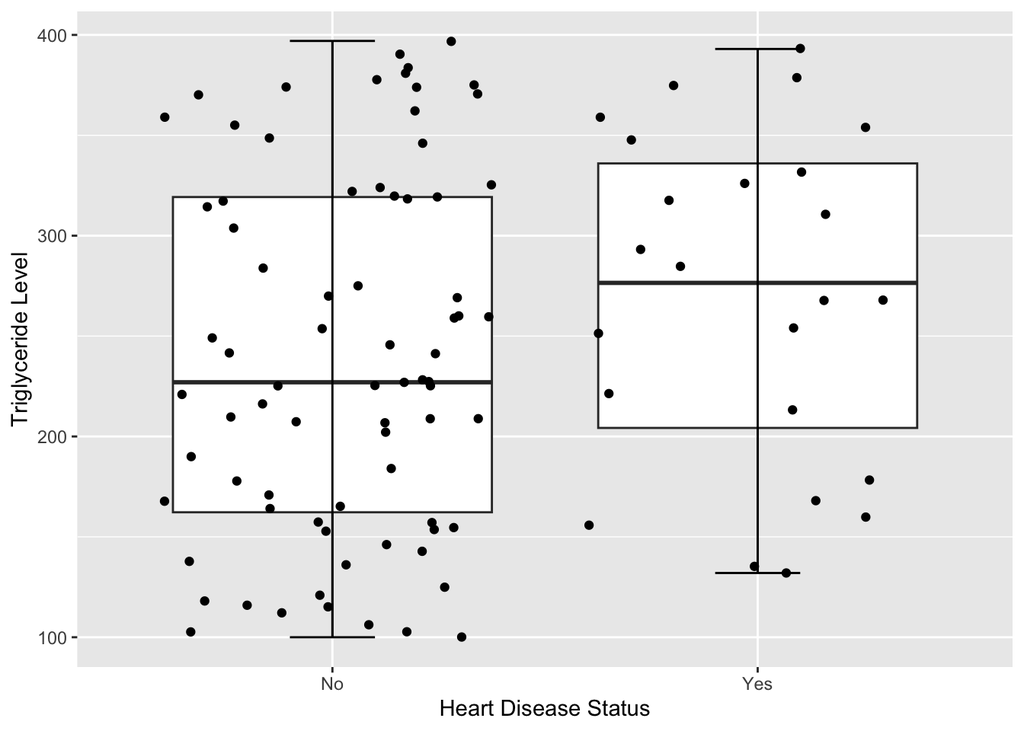

```r
data %>%
  ggplot(aes(x = `Heart Disease Status`, y = `Triglyceride Level`)) +
  geom_boxplot(outlier.shape = NA) +
  stat_boxplot(geom = "errorbar", width = 0.2) +
  geom_jitter()
```

You can also color code the boxes, bars, and individual data points by groups. To do so, simply add an argument `color` in the aesthetics function `aes()`.

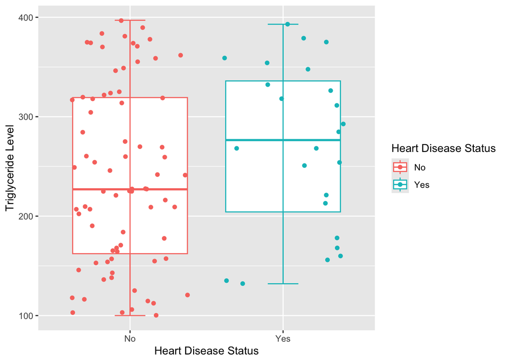

```r
# color by groups
data %>%
  ggplot(aes(x = `Heart Disease Status`, y = `Triglyceride Level`, color = `Heart Disease Status`)) +
  geom_boxplot(outlier.shape = NA) +
  stat_boxplot(geom = "errorbar", width = 0.2) +
  geom_jitter()
```